# IPUMS-I Wealth Index - Index 2

### Pulling/manipulating data before importing to R

In IPUMS-I: Select variables to include as many of  
(COUNTRY, YEAR, SAMPLE, SERIAL, PERNUM, PERWT, RESIDENT preselected),  
HHWT, PERSONS, OWNERSHIP, ELECTRIC, WATSUP, SEWAGE, FUELCOOK, TRASH, HEAT, AIRCON, ROOMS, TOILET, FLOOR, WALL, ROOF,  
PHONE, CELL, AUTOS, REFRIG, TV, RADIO,  
CHBORN, SCHOOL, EDATTAIN, AND OCCISCO  
as are available.

In JMP or SAS: Uncheck “Use value labels” for all variables that were not preselected. This codebook will not run with value labels.

Note: Search for USER ACTION to find places in this code that require user consideration for each country sample.

### Importing data

```r
#USER ACTION: replace "Zambia_2010.csv" with data from country of interest
#country <- read.csv("<csv filename here>")
country <- read.csv("Zambia_2010.csv")
```

### Building the Index

##### Subsetting country (refer to index comparison table provided by Minnesota Population Center)

```r
country_2 = country %>%
  filter(Person.number == 1) %>%
  select(-c(
  IPUMS.sample.identifier,
  Ownership.of.dwelling..detailed.version.,
  Person.number,
  Residence.status..de.facto..de.jure,
  Children.ever.born,
  School.attendance,
  Educational.attainment..international.recode..general.version.,
  Educational.attainment..international.recode..detailed.version.,
  Occupation..ISCO.general,
  Trash.disposal,
  #Central.heating,
  #Air.conditioning,
  Telephone.availability,
  Cellular.phone.availability,
  Automobiles.available,
  Refrigerator,
  Television.set,
  Radio.in.household
  ))
```

##### Making the variables

USER ACTION:  
* Check this code for each data set. Comment out lines of code for variables unavailable in country sample.  
* Pay special attention to SEWAGE (see notes below) - needs to be checked for each sample  
* As written, this code removes NIU, Unknown for each variable. User may remove or change filter commands to include NIU, Unknown.

Make “Not in” function (used for all indices):

```r
'%!in%' <- function(x,y)!('%in%'(x,y))
```

Relevel variables:

```r
#Making ownership.1 (Owned or Not owned)
country_2 <- country_2 %>% filter(Ownership.of.dwelling..general.version. %!in% c(0,9)) %>% mutate(ownership.1 = ifelse(Ownership.of.dwelling..general.version. == 1, "Owned","Not owned"))
#Making electric.1 (Has electricity or No electricity)
country_2 <- country_2 %>% filter(Electricity %!in% c(0,9)) %>% mutate(electric.1 = ifelse(Electricity == 1, "Has electricity", "No electricity"))
#Making water.supply.1 (Access to piped water or No access to piped water)
country_2 <- country_2 %>% filter(Water.supply %!in% c(0,99)) %>% mutate(water.supply.1 = ifelse(Water.supply %in% 10:18, "Access to piped water","No access to piped water"))
#Making sewage.general.1 (Sewage system or No sewage system)
country_2 <- country_2 %>% filter(Sewage %!in% c(0,99)) %>% mutate(sewage.general.1 = ifelse(Sewage %in% 10:12, "Sewage system", "No sewage system"))
#Making cooking.fuel.1 (Cook with fossil fuel or elec, Cook with solid fuels, or Cook with other fuel)
country_2 <- country_2 %>% filter(Cooking.fuel %!in% c(0,99)) %>% mutate(cooking.fuel.1 = ifelse(Cooking.fuel %in% c(20,30:47,62:65), "Cook with fossil fuel or elec", ifelse(Cooking.fuel %in% c(50:56,61), "Cook with solid fuels", "Cook with other fuel")))
#See the releveling section of Index 1, variable number.ppl.per.room.1 for notes regarding this calculation
#Making number.ppl.per.room.1
country_2 <- country_2 %>% filter(Number.of.rooms %!in% c(98,99)) %>% mutate(Number.of.rooms.1 = ifelse(Number.of.rooms == 0, 1, Number.of.rooms))
country_2 <- country_2 %>% mutate(number.ppl.per.room.1 = Number.of.person.records.in.the.household/Number.of.rooms.1)
country_2$number.ppl.per.room.1 <- round(country_2$number.ppl.per.room.1)
country_2$number.ppl.per.room.1 <- as.integer(country_2$number.ppl.per.room.1)
#Different binning: Making bin.number.ppl.per.room.1
country_2 <- country_2 %>% mutate(bin.number.ppl.per.room.1 = ifelse(number.ppl.per.room.1 %in% 0:2, "0-2 ppl per room",ifelse(number.ppl.per.room.1 %in% 3:9, "3-9 ppl per room","10+ ppl per room")))
#Further split cutoffs for binning: Making alt.bin.number.ppl.per.room.1
country_2 <- country_2 %>% mutate(alt.bin.number.ppl.per.room.1 = ifelse(number.ppl.per.room.1 %in% 0:1, "0-1 ppl per room", ifelse(number.ppl.per.room.1 %in% 2:4, "2-4 ppl per room", ifelse(number.ppl.per.room.1 %in% 5:9, "5-9 ppl per room", "10+ ppl per room"))))
#Making toilet.1 (Toilet or No toilet)
country_2 <- country_2 %>% filter(Toilet %!in% c(0,99)) %>% mutate(toilet.1 = ifelse(Toilet %in% 10:11, "No toilet","Toilet"))
#Making dwelling.1 (Has cement structures [cement floor, cement wall, or cement roof] or has No cement structures) - need to create each of floor.1, wall.1, roof.1 first
#floor.1 (1 [Finished] or 0 [Unfinished])
country_2 <- country_2 %>% filter(Floor.material %!in% c(0,999)) %>% mutate(floor.1 = ifelse(Floor.material %in% c(200:234,236), 1, 0))
#wall.1 (1 [Cement] or 0 [Not cement])
country_2 <- country_2 %>% filter(Wall.or.building.material %!in% c(0,999)) %>% mutate(wall.1 = ifelse(Wall.or.building.material %in% c(500:513,515:523,545,546), 1, 0))
#roof.1 (1 [Cement] or 0 [Not cement])
country_2 <- country_2 %>% filter(Roof.material %!in% c(0,99)) %>% mutate(roof.1 = ifelse(Roof.material %in% c(10:24,29), 1, 0))
#floor.wall.roof.1 (sum of floor.1, wall.1, roof.1)
country_2 <- country_2 %>% mutate(floor.wall.roof.1 = floor.1+wall.1+roof.1)
#dwelling.1
country_2 <- country_2 %>% mutate(dwelling.1 = ifelse(floor.wall.roof.1 > 0, "Cement structures", "No cement structures"))
```

### Beginning the Multiple Component Analysis (Categorical variable counterpart to Principal Component Analysis)

USER ACTION:  
Note: Comment out lines of code for variables unavailable in country sample.  
Note: Review Sewage variable choice before running this chunk.

Convert all newly created variables to factors:

```r
country_2$ownership.1 = as.factor(country_2$ownership.1)
country_2$electric.1 = as.factor(country_2$electric.1)
country_2$water.supply.1 = as.factor(country_2$water.supply.1)
country_2$sewage.general.1 = as.factor(country_2$sewage.general.1)
country_2$cooking.fuel.1 = as.factor(country_2$cooking.fuel.1)
country_2$number.ppl.per.room.1 = as.factor(country_2$number.ppl.per.room.1)
country_2$bin.number.ppl.per.room.1 = as.factor(country_2$bin.number.ppl.per.room.1)
country_2$alt.bin.number.ppl.per.room.1 = as.factor(country_2$alt.bin.number.ppl.per.room.1)
country_2$toilet.1 = as.factor(country_2$toilet.1)
country_2$dwelling.1 = as.factor(country_2$dwelling.1)
```

Setting row names to the Household.serial.number:  
USER ACTION: If using a sample containing more than one country, the row name needs to contain the full IPUMS idendifier and Household.serial.number to track the individual houses through the full MCA analysis.

```r
row.names(country_2) = country_2$Household.serial.number
```

##### Building the MCA model:

USER ACTION: Comment out variables unavailable in the country sample:

```r
country_2.sub = select(country_2, c(ownership.1,
                                      electric.1,
                                      water.supply.1,
                                      sewage.general.1,
                                      cooking.fuel.1,
                                      bin.number.ppl.per.room.1,
                                      toilet.1,
                                      dwelling.1))
country_2.mca = MCA(country_2.sub,row.w = country_2$Household.weight, graph = FALSE)
```

Visualizing variable loadings:

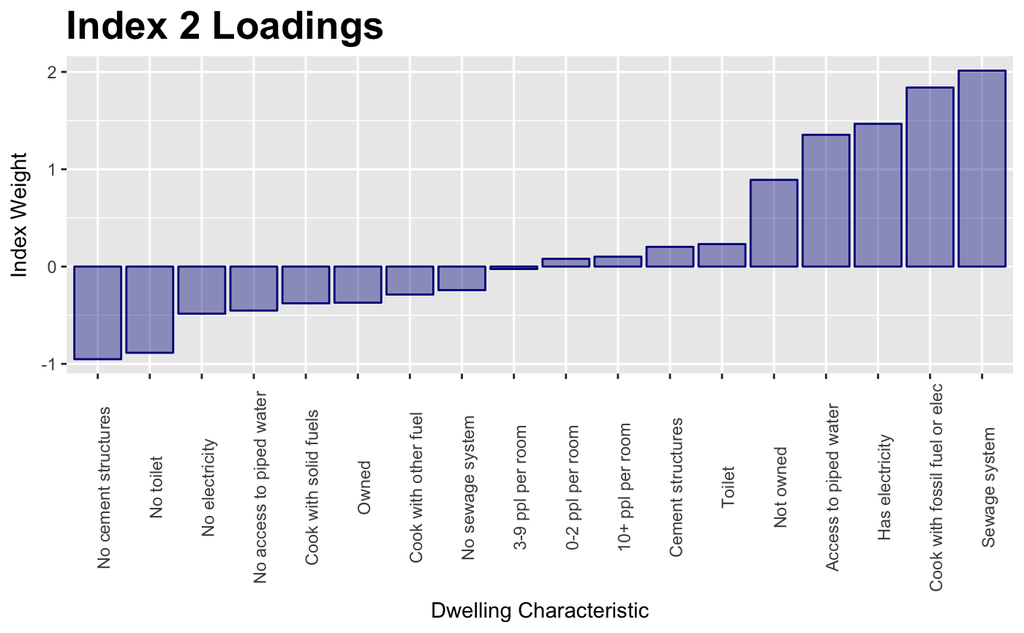

Data frame of household score:

```r
households_2 <- data.frame(country_2.mca$ind$coord[,1])
households_2$ID <- rownames(households_2)
colnames(households_2) <- c("score","ID")
```

Breaking household index score into quintiles:

```r
households_2.quint <- arrange(households_2,score)
households_2.quint$rows <- c(1:nrow(households_2))
households_2.quint <- households_2.quint %>%
  mutate(quintiles = ifelse(rows >= 1 & rows < nrow(households_2)/5, "Q1", ifelse(
    rows >= nrow(households_2)/5 & rows < 2*nrow(households_2)/5, "Q2", ifelse(
      rows >= 2*nrow(households_2)/5 & rows < 3*nrow(households_2)/5, "Q3", ifelse(
        rows >= 3*nrow(households_2)/5 & rows < 4*nrow(households_2)/5, "Q4", "Q5"
        )
      )
    )
  ))
```

Subsetting country to include only selected outcomes:

```r
outcomes <- country %>%
  select(c(Household.serial.number, Household.weight, Person.number, Person.weight,
           Children.ever.born, School.attendance, Occupation..ISCO.general))
```

##### Average number of children born per woman

Three approaches to represent household wealth versus fertility rate:

1. Household trends by wealth quintile

Finding average number of children born per woman for each household:

```r
#Exclude individuals who are not in universe (Universe is women of childbearing age)
children <- outcomes %>% filter(Children.ever.born %!in% c(98, 99))
#Find the average number of children per woman for each household
children <- children %>%
  group_by(Household.serial.number) %>%
  dplyr::summarise(avg_ch = mean(Children.ever.born))
colnames(children) <- c("ID", "Avg.num.child")
children$ID <- as.character(children$ID)
```

Joining household index score with average number of children born per woman, then averaging by quintiles:

```r
#Join tables
households_2.quint.children.group <- inner_join(households_2.quint,children.group,by="ID")
#Group by quintiles, then summarise by average number of children (average of the average per woman for each household)
households_2.quint.children.group <- households_2.quint.children.group %>%
  group_by(quintiles) %>%
  dplyr::summarise(avg.child.woman = mean(Avg.num.child))
households_2.quint.children.group$quintiles <- as.factor(households_2.quint.children.group$quintiles)
#USER ACTION: The user may need to relevel the quintiles if they are out of order
#households_2.quint.children.group$quintiles = factor(households_2.quint.children.group$quintiles,levels(households_2.quint.children.group$quintiles)[c(3,2,1,4,5)])
```

Plot average number of children per woman of each quintile:

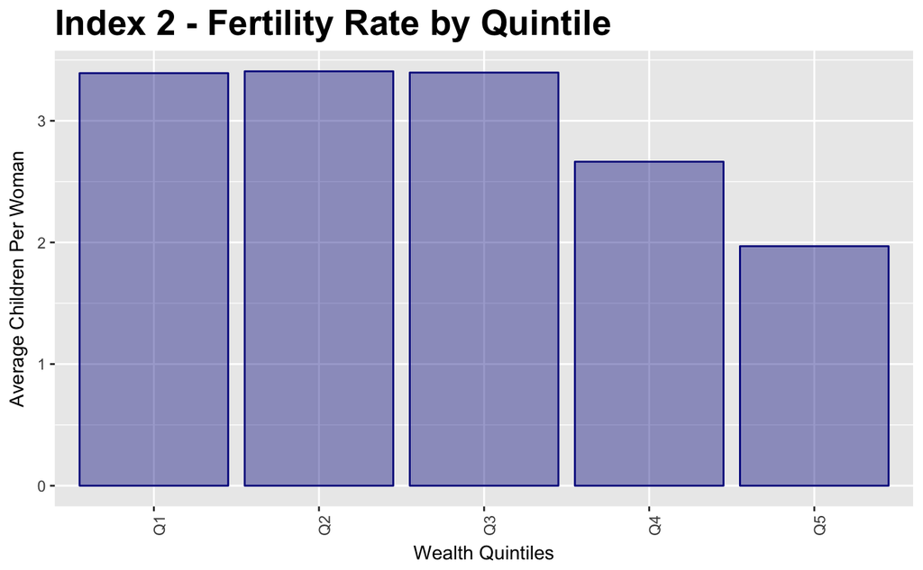

2. Anova analysis relating wealth index score to number of children per woman

```r
children$Household.serial.number <- as.character(children$Household.serial.number)
#Join tables for individual household wealth scores and number of children born
households_2.children <- inner_join(households_2, children, by = c("ID" = "Household.serial.number"))
#Making a model to predict household score from number of children born
households_2.children.lm <- lm(households_2.children$score ~
                                 as.factor(households_2.children$Children.ever.born),
                               weights = households_2.children$Person.weight)
summary(households_2.children.lm)
```

```
Call:
lm(formula = households_2.children$score ~ as.factor(households_2.children$Children.ever.born),
    weights = households_2.children$Person.weight)

Residuals:
    Min      1Q  Median      3Q     Max
-2.8203 -1.3716 -0.6314  1.0634  5.7107

Coefficients:
                                                       Estimate Std. Error t value Pr(>|t|)
(Intercept)                                            0.135020   0.001624  83.117  < 2e-16 ***
as.factor(households_2.children$Children.ever.born)1   0.011597   0.003678   3.153  0.00162 **
as.factor(households_2.children$Children.ever.born)2  -0.031417   0.003811  -8.243  < 2e-16 ***
as.factor(households_2.children$Children.ever.born)3  -0.079973   0.003959 -20.200  < 2e-16 ***
as.factor(households_2.children$Children.ever.born)4  -0.136569   0.004124 -33.113  < 2e-16 ***
as.factor(households_2.children$Children.ever.born)5  -0.195987   0.004452 -44.022  < 2e-16 ***
as.factor(households_2.children$Children.ever.born)6  -0.234089   0.004706 -49.745  < 2e-16 ***
as.factor(households_2.children$Children.ever.born)7  -0.269828   0.005375 -50.204  < 2e-16 ***
as.factor(households_2.children$Children.ever.born)8  -0.298276   0.005917 -50.407  < 2e-16 ***
as.factor(households_2.children$Children.ever.born)9  -0.313210   0.006772 -46.249  < 2e-16 ***
as.factor(households_2.children$Children.ever.born)10 -0.348841   0.004966 -70.241  < 2e-16 ***
---
Signif. codes:  0 ‘***’ 0.001 ‘**’ 0.01 ‘*’ 0.05 ‘.’ 0.1 ‘ ’ 1

Residual standard error: 2.051 on 398691 degrees of freedom
Multiple R-squared:  0.03145,   Adjusted R-squared:  0.03142
F-statistic:  1294 on 10 and 398691 DF,  p-value: < 2.2e-16
```

3. Boxplots relating individual women’s fertility to their household’s wealth score

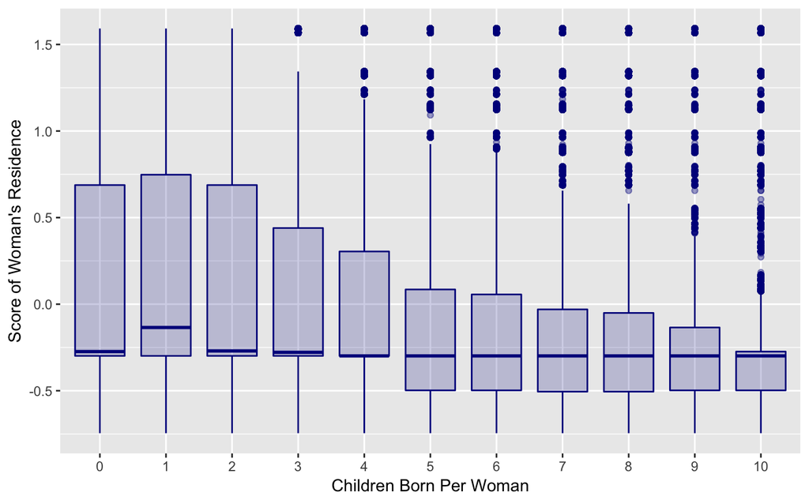

```r
#Side-by-side boxplots
ggplot(households_2.children, aes(x=as.factor(Children.ever.born), y = score)) +
  geom_boxplot(color = "darkblue", fill = "darkblue", alpha = 0.2,
               outlier.color = "darkblue", outlier.fill = "darkblue", outlier.alpha = 0.4) +
  ylab("Score of Woman's Residence") +
  xlab("Children Born Per Woman")
```

##### School Attendance

Two approaches to represent household wealth versus school attendance:

Finding total number of people in each household currently in school:

```r
#Exclude irrelevant variables
school <- outcomes %>% select(c(Household.serial.number, Household.weight, Person.number,
                                Person.weight, School.attendance))
school$Household.serial.number <- as.character(school$Household.serial.number)
#Exclude NIU, Unknown
school <- school %>% filter(School.attendance %!in% c(0,9))
#Assign 1 if "Yes, in school" and zero otherwise (counts number of people in household currently in school)
school <- school %>%
  mutate(school.indicator = ifelse(School.attendance == 1, 1, 0))
#Find the number of people currently in school in the household.
#Also, find the mean Household.weight per house (will be the same for each housemember) to preserve Household.weight in the new dataframe
school.group <- school %>%
  group_by(Household.serial.number) %>%
  dplyr::summarise(total.in.school = sum(school.indicator),
                   Household.weight = mean(Household.weight))
```

1. Anova analysis relating wealth index score to number of people in the household in school

```r
#Join tables for individual household wealth scores and number of people in the household in school
households_2.school <- inner_join(school.group, households_2,
                                  by = c("Household.serial.number" = "ID"))
#Making a model to predict household score from school attendance in the household
school.lm <- lm(households_2.school$score ~ as.factor(households_2.school$total.in.school),
                weights = households_2.school$Household.weight)
summary(school.lm)
```

```
Call:
lm(formula = households_2.school$score ~ as.factor(households_2.school$total.in.school),
    weights = households_2.school$Household.weight)

Residuals:
    Min      1Q  Median      3Q     Max
-3.4853 -1.2930 -0.5987  0.8593  5.3804

Coefficients:
                                                  Estimate Std. Error t value Pr(>|t|)
(Intercept)                                      -0.109387   0.001958 -55.867  < 2e-16 ***
as.factor(households_2.school$total.in.school)1   0.120023   0.003424  35.050  < 2e-16 ***
as.factor(households_2.school$total.in.school)2   0.166889   0.003652  45.703  < 2e-16 ***
as.factor(households_2.school$total.in.school)3   0.201250   0.004231  47.564  < 2e-16 ***
as.factor(households_2.school$total.in.school)4   0.268473   0.005277  50.876  < 2e-16 ***
as.factor(households_2.school$total.in.school)5   0.327860   0.007538  43.492  < 2e-16 ***
as.factor(households_2.school$total.in.school)6   0.374671   0.011507  32.561  < 2e-16 ***
as.factor(households_2.school$total.in.school)7   0.446001   0.019551  22.812  < 2e-16 ***
as.factor(households_2.school$total.in.school)8   0.491149   0.028054  17.507  < 2e-16 ***
as.factor(households_2.school$total.in.school)9   0.477860   0.048707   9.811  < 2e-16 ***
as.factor(households_2.school$total.in.school)10  0.403102   0.071484   5.639 1.71e-08 ***
as.factor(households_2.school$total.in.school)11  0.300952   0.104524   2.879  0.00399 **
as.factor(households_2.school$total.in.school)12  0.206419   0.152090   1.357  0.17472
as.factor(households_2.school$total.in.school)13  0.277123   0.237004   1.169  0.24229
as.factor(households_2.school$total.in.school)14  0.675489   0.362023   1.866  0.06206 .
as.factor(households_2.school$total.in.school)15  0.632000   0.443383   1.425  0.15404
as.factor(households_2.school$total.in.school)16  0.639656   0.362023   1.767  0.07725 .
as.factor(households_2.school$total.in.school)17 -0.164487   0.627036  -0.262  0.79307
as.factor(households_2.school$total.in.school)18  0.155063   0.362023   0.428  0.66842
as.factor(households_2.school$total.in.school)23  1.453337   0.627036   2.318  0.02046 *
---
Signif. codes:  0 ‘***’ 0.001 ‘**’ 0.01 ‘*’ 0.05 ‘.’ 0.1 ‘ ’ 1

Residual standard error: 1.983 on 250391 degrees of freedom
Multiple R-squared:  0.0278,    Adjusted R-squared:  0.02773
F-statistic: 376.8 on 19 and 250391 DF,  p-value: < 2.2e-16
```

2. Boxplots relating household’s school attendance to household’s wealth score

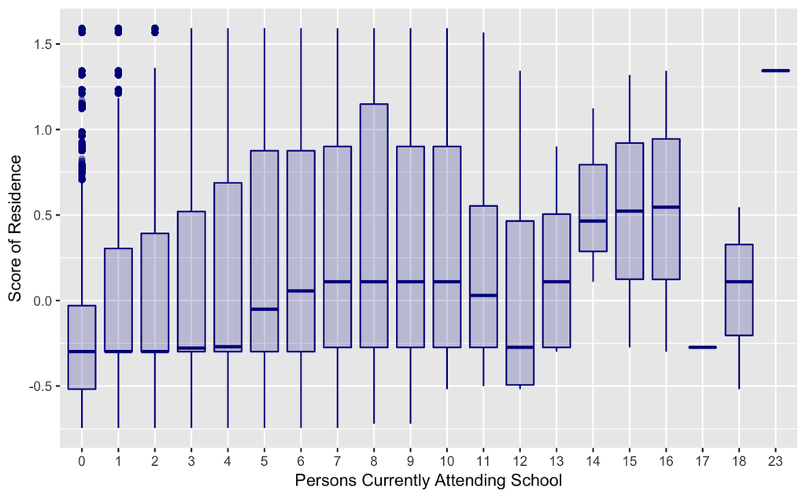

```r
#Side-by-side boxplots
ggplot(households_2.school, aes(x=as.factor(total.in.school), y = score)) +
  geom_boxplot(color = "darkblue", fill = "darkblue", alpha = 0.2,
               outlier.color = "darkblue", outlier.fill = "darkblue", outlier.alpha = 0.4) +
   xlab("Persons Currently Attending School") +
   ylab("Score of Residence")
```

##### Proportion of household employed in high skilled occupation

1. Household trends by wealth quintile

Finding proportion of household members employed in high skilled occupation:

```r
#Exclude persons not in universe (Persons of working age), label occupations as high (1) or not high (0) skill
occupation <- outcomes %>%
  select(-c(Children.ever.born, School.attendance)) %>%
  filter(Occupation..ISCO.general %!in% c(98,99)) %>%
  mutate(high_occ = ifelse(Occupation..ISCO.general %in% c(1:3),1,0))
#Find proportion in high skilled occupation in household (Sum of high_occ divided by the number of people of working age in the household)
occupation.group <- occupation %>%
  group_by(Household.serial.number) %>%
  dplyr::summarise(prop_high_occ = sum(high_occ)/n())
colnames(occupation.group) <- c("ID", "prop_high_occ")
occupation.group$ID <- as.character(occupation.group$ID)
```

Joining household index score with proportion in high occupations per household, then averaging by quintiles:

```r
#Join tables
households_2.quint.occupation.group <- inner_join(households_2.quint,occupation.group,by="ID")
#Group by quintiles, summarise by average proportion of high occupation people in household
households_2.quint.occupation.group <- households_2.quint.occupation.group %>%
  group_by(quintiles) %>%
  dplyr::summarise(avg_prop_high_occ = mean(prop_high_occ))
households_2.quint.occupation.group$quintiles <- as.factor(households_2.quint.occupation.group$quintiles)
#USER ACTION: The user may need to relevel the quintiles if they are out of order
#households_2.quint.occupation.group$quintiles = factor(households_2.quint.occupation.group$quintiles,levels(households_2.quint.occupation.group$quintiles)[c(3,2,1,4,5)])
```

Plot average proportion of people employed in high occupations per household of each quintile

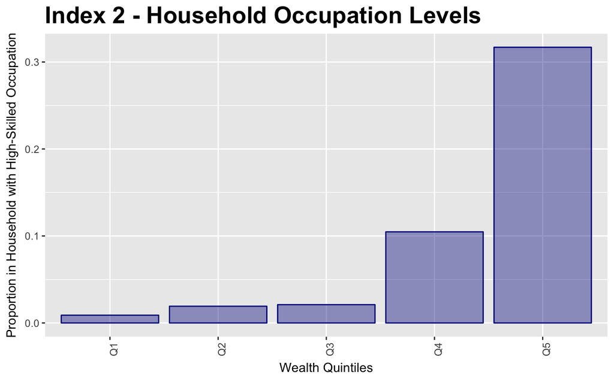

2. Boxplots relating individual’s occupation to their household’s wealth score  
   Joining household index score with proportion in high occupations per household:

```r
occupation$Household.serial.number <- as.character(occupation$Household.serial.number)
#Join tables
households_2.occupation <- inner_join(occupation, households_2,
                                      by = c("Household.serial.number" = "ID"))
households_2.occupation$Occupation..ISCO.general <-
  as.character(households_2.occupation$Occupation..ISCO.general)
```

Plot household wealth scores by occupation:

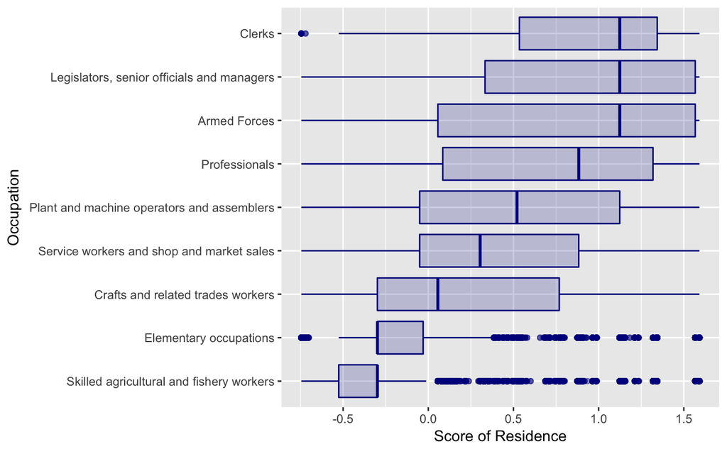

```r
#The following line of code will print the occupation codes of occupations not present in the country data set.
households_2.occupation$Occupation..ISCO.general <-  revalue(households_2.occupation$Occupation..ISCO.general, c("1" = "Legislators, senior officials and managers", "2" = "Legislators, senior officials and managers", "3" = "Professionals", "Technicians and associate professionals", "4" = "Clerks", "5" = "Service workers and shop and market sales", "6" = "Skilled agricultural and fishery workers", "7" = "Crafts and related trades workers", "8" = "Plant and machine operators and assemblers", "9" = "Elementary occupations", "10" = "Armed Forces", "11" = "Other occupations, unspecified or n.e.c.", "97" = "Response suppressed"))
#Side-by-side boxplots
ggplot(households_2.occupation, aes(x=reorder(Occupation..ISCO.general, score), y = score)) +
  geom_boxplot(color = "darkblue", fill = "darkblue", alpha = 0.2,
               outlier.color = "darkblue", outlier.fill = "darkblue", outlier.alpha = 0.4) +
  ylab("Score of Residence") +
  xlab("Occupation") +
  coord_flip()
```